# Chapter 6: Analysis of longitudinal data

In this chapter I'm implementing the analyses of Chapter 8 of MABS using the RATS data, and the analyses of Chapter 9 of MABS using the BPRS data.

## RATS data

First, let's load the RATS data in long form and check the structure.

```r
RATSL <- read.csv("~/Desktop/IODS/R project for ODS/IODS-project/data/RATSL.csv", row.names = 1)
str(RATSL)
```

```
## 'data.frame':    176 obs. of  5 variables:
##  $ ID    : int  1 2 3 4 5 6 7 8 9 10 ...
##  $ Group : int  1 1 1 1 1 1 1 1 2 2 ...
##  $ WD    : chr  "WD1" "WD1" "WD1" "WD1" ...
##  $ Weight: int  240 225 245 260 255 260 275 245 410 405 ...
##  $ Time  : int  1 1 1 1 1 1 1 1 1 1 ...
```

Some variables need to be factored again.

```r
library(tidyverse)
RATSL$ID <- factor(RATSL$ID)
RATSL$Group <- factor(RATSL$Group)
glimpse(RATSL)
```

```
## Rows: 176
## Columns: 5
## $ ID     <fct> 1, 2, 3, 4, 5, 6, 7, 8, 9, 10, 11, 12, 13, 14, 15, 16, 1, 2, 3…
## $ Group  <fct> 1, 1, 1, 1, 1, 1, 1, 1, 2, 2, 2, 2, 3, 3, 3, 3, 1, 1, 1, 1, 1,…
## $ WD     <chr> "WD1", "WD1", "WD1", "WD1", "WD1", "WD1", "WD1", "WD1", "WD1",…
## $ Weight <int> 240, 225, 245, 260, 255, 260, 275, 245, 410, 405, 445, 555, 47…
## $ Time   <int> 1, 1, 1, 1, 1, 1, 1, 1, 1, 1, 1, 1, 1, 1, 1, 1, 8, 8, 8, 8, 8,…
```

First, I look at the data graphically. In the plot below we see the three groups in different plots, time is on the x-axis and body weight is on the y-axis. The body weight of the rats increase in general during the study, and it seems that in most cases if the body weight is higher in the beginning, it also stays higher compared to the others.

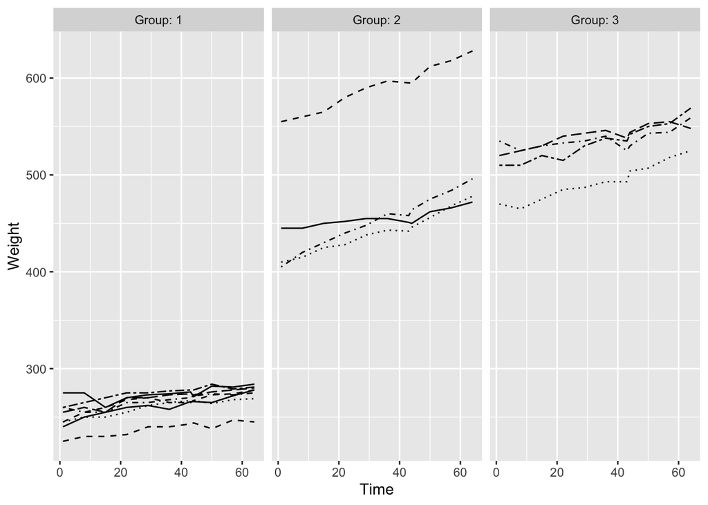

```r
library(ggplot2)
library(dplyr)

ggplot(RATSL, aes(x = Time, y = Weight, linetype = ID)) +
  geom_line() +
  scale_linetype_manual(values = rep(1:10, times=4)) +
  facet_grid(. ~ Group, labeller = label_both) +
  theme(legend.position = "none") +
  scale_y_continuous(limits = c(min(RATSL$Weight), max(RATSL$Weight)))
```

Next, I look how the same plot seems with standardized data. With the standardized data, the relatioships of rats compared to each other seem to stay similar to the previous plot. However, the pattern of incresing body weight does not seem to hold. Especially in group 3 the rats seem lo lose weight during the study rather than gaining weight.

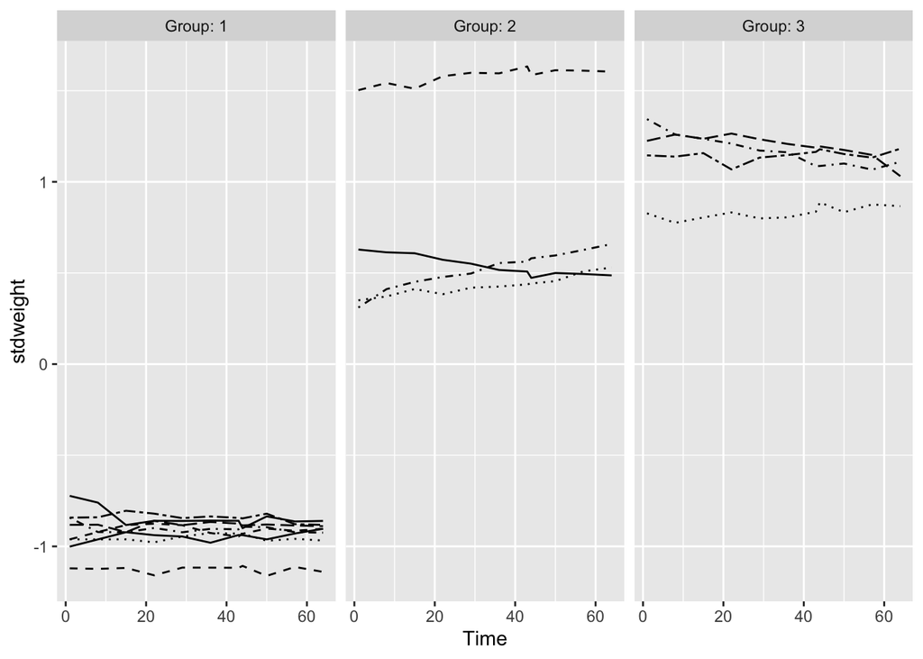

```r
RATSL <- RATSL %>%
  group_by(Time) %>%
  mutate(stdweight = (Weight - mean(Weight))/sd(Weight)) %>%
  ungroup()

ggplot(RATSL, aes(x = Time, y = stdweight, linetype = ID)) +
  geom_line() +
  scale_linetype_manual(values = rep(1:10, times=4)) +
  facet_grid(. ~ Group, labeller = label_both) +
  theme(legend.position = "none") +
  scale_y_continuous(limits = c(min(RATSL$stdweight), max(RATSL$stdweight)))
```

```r
RATSS <- RATSL %>%
  group_by(Group, Time) %>%
  summarise(mean = mean(Weight), se = sd(Weight)/sqrt(length(unique(RATSL$Time)))) %>%
  ungroup()
```

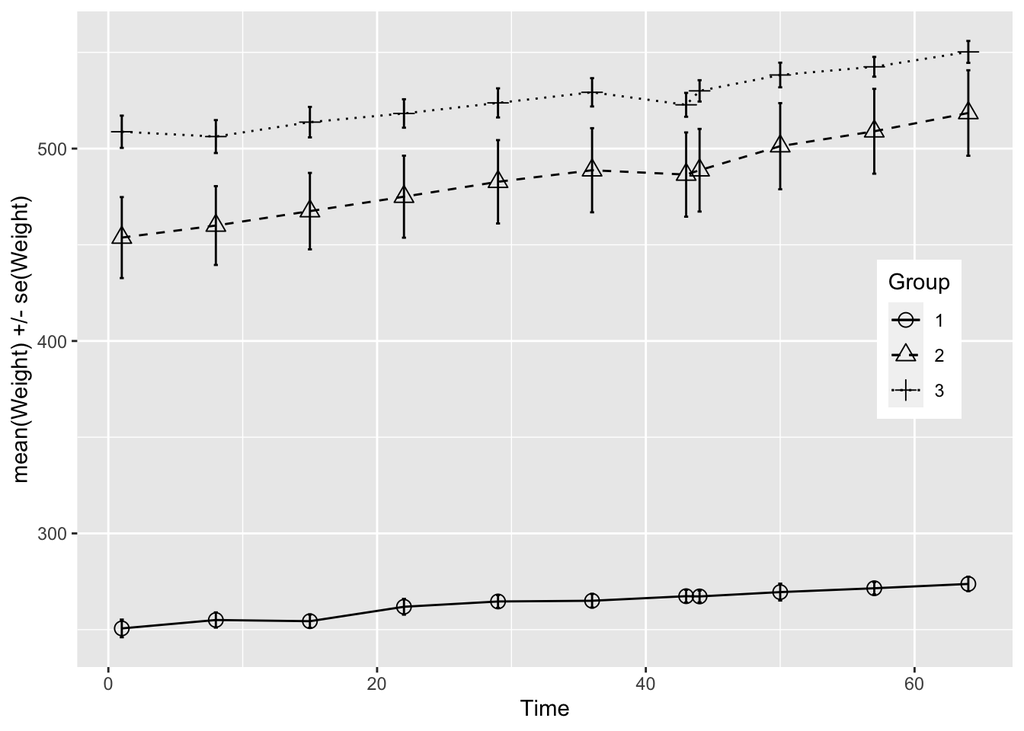

```r
ggplot(RATSS, aes(x = Time, y = mean, linetype = Group, shape = Group)) +
  geom_line() +
  scale_linetype_manual(values = c(1, 2, 3)) +
  geom_point(size=3) +
  scale_shape_manual(values = c(1, 2, 3)) +
  geom_errorbar(aes(ymin=mean-se, ymax=mean+se, linetype="1"), width=0.3) +
  theme(legend.position = c(0.9, 0.5)) +
  scale_y_continuous(name = "mean(Weight) +/- se(Weight)")
```

To spot possible outliers, let's look at another summary plot. In the box plot below we see that group 2 has an outlier that seems to have a big effect on the group mean. Groups 1 and 3 also have outliers, but they are not so heavily affecting the mean of the whole group.

```r
RATSS_2 <- RATSL %>%
  filter(Time > 1) %>%
  group_by(Group, ID) %>%
  summarise(mean=mean(Weight)) %>%
  ungroup()
```

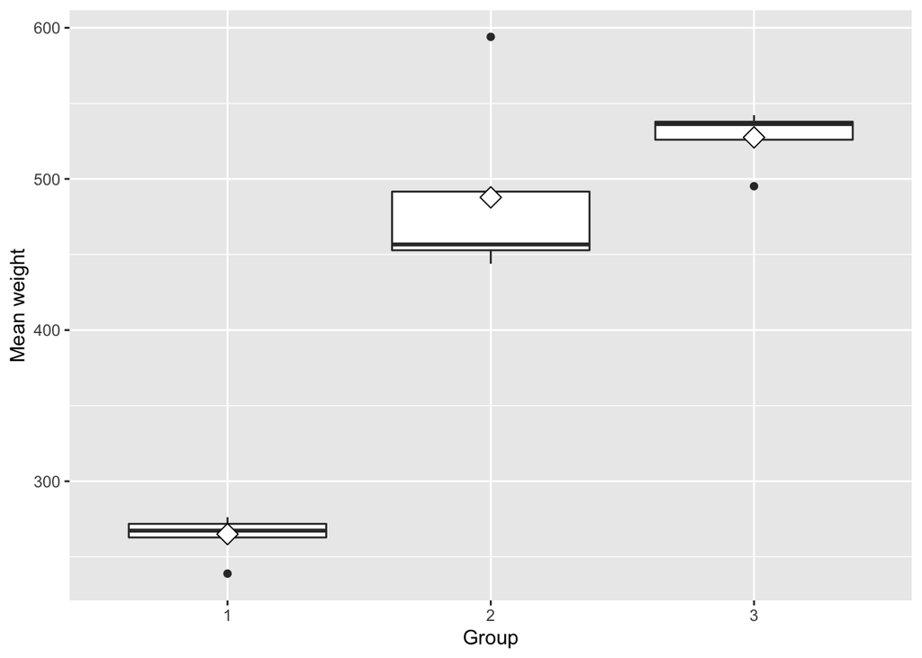

```r
ggplot(RATSS_2, aes(x = Group, y = mean)) +
  geom_boxplot() +
  stat_summary(fun.y = "mean", geom = "point", shape=23, size=4, fill = "white") +
  scale_y_continuous(name = "Mean weight")
```

Let's remove the outlier in group 2 and plot again. In the plot we see that the variance in gruop 2 is clearly reduced.

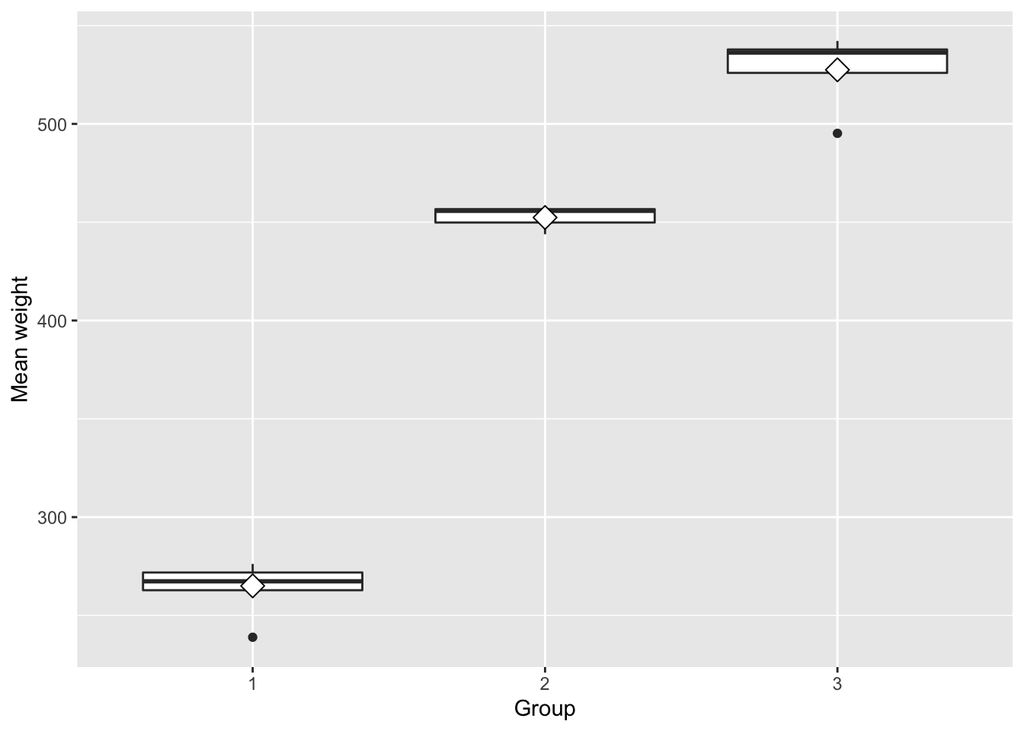

```r
RATSS_3 <- filter(RATSS_2, mean < 550)

ggplot(RATSS_3, aes(x = Group, y = mean)) +
  geom_boxplot() +
  stat_summary(fun.y = "mean", geom = "point", shape=23, size=4, fill = "white") +
  scale_y_continuous(name = "Mean weight")
```

Because we are dealing with three different groups and cannot therefore do a t-test to compare all means at the same time, let's look if the means are significantly different using anova. First I need to add the baselone from the first week. Here, I'm using the data with the outlier in group 2. The baseline is significantly related to the mean body weight, but the group does not seem to be significant.

```r
RATS <- read.csv("~/Desktop/IODS/R project for ODS/IODS-project/data/RATS.csv", row.names = 1)

RATSS_4 <- mutate(RATSS_2, baseline=RATS$WD1)

lm_RATS <- lm(mean ~ baseline + Group, data = RATSS_4)

anova(lm_RATS)
```

```
## Analysis of Variance Table
##
## Response: mean
##           Df Sum Sq Mean Sq   F value   Pr(>F)
## baseline   1 253625  253625 1859.8201 1.57e-14 ***
## Group      2    879     439    3.2219  0.07586 .
## Residuals 12   1636     136
## ---
## Signif. codes:  0 '***' 0.001 '**' 0.01 '*' 0.05 '.' 0.1 ' ' 1
```

## BPRS data

Then, let's load the BPRS data in long form.

```r
BPRSL <- read.csv("~/Desktop/IODS/R project for ODS/IODS-project/data/BPRSL.csv", row.names = 1)
str(BPRSL)
```

```
## 'data.frame':    360 obs. of  5 variables:
##  $ treatment : int  1 1 1 1 1 1 1 1 1 1 ...
##  $ subject   : int  1 2 3 4 5 6 7 8 9 10 ...
##  $ weeks     : chr  "week0" "week0" "week0" "week0" ...
##  $ bprs_score: int  42 58 54 55 72 48 71 30 41 57 ...
##  $ week      : int  0 0 0 0 0 0 0 0 0 0 ...
```

Again, some variables need to be factored.

```r
BPRSL$treatment <- as.factor(BPRSL$treatment)
BPRSL$subject <- as.factor(BPRSL$subject)
```

Plotting the data and ignoring the repeated measures structure.

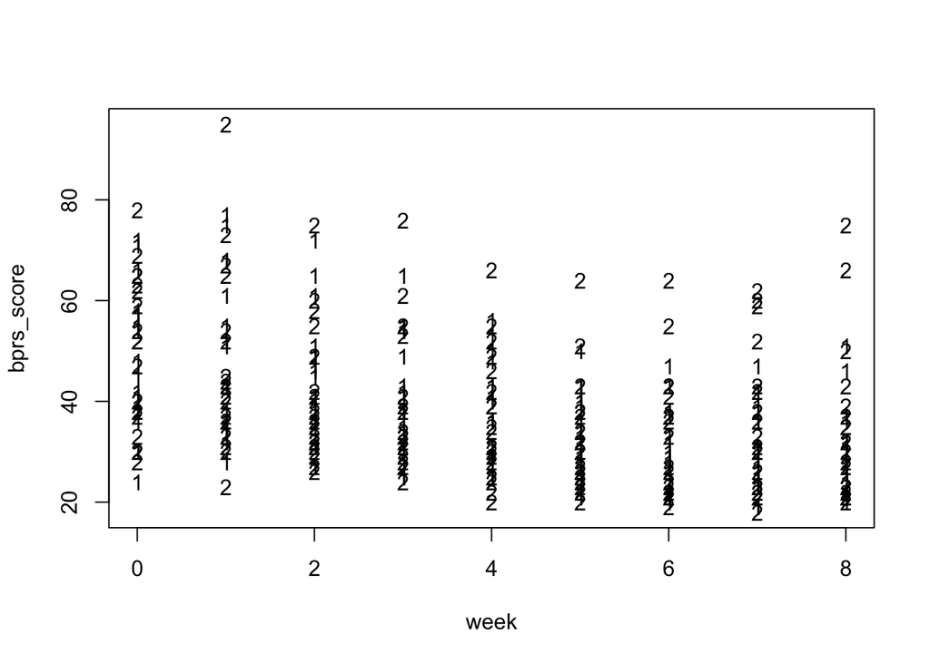

```r
plot(bprs_score ~ week, data=BPRSL, pch=c("1", "2")[treatment])
```

Another plot with repeated measures taken into account. In general, the bprs score seems to go down during the weeks, but the treatment groups don't seem to have any difference between them.

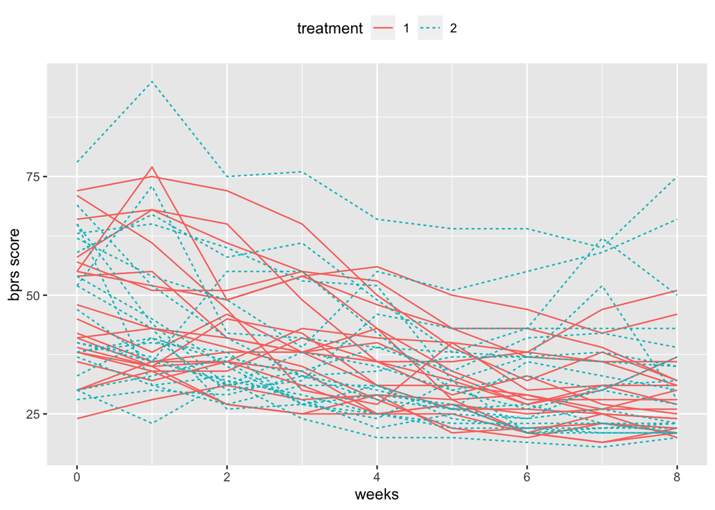

```r
plot1 <- ggplot(BPRSL, aes(x = week, y = bprs_score, group=subject)) +
        geom_line(aes(color=treatment, linetype=treatment)) +
        scale_x_continuous(name = "weeks", breaks = seq(0, 8, by=2)) +
        scale_y_continuous(name = "bprs score") +
        theme(legend.position = "top")

plot1
```

Fitting a linear regression model where repeated measures structure is not considered. Results show that time (in weeks) is significantly related to bprs score, but treatment group is not.

```r
fit1 <- lm(bprs_score ~ week + treatment, data = BPRSL)
summary(fit1)
```

```
##
## Call:
## lm(formula = bprs_score ~ week + treatment, data = BPRSL)
##
## Residuals:
##     Min      1Q  Median      3Q     Max
## -22.454  -8.965  -3.196   7.002  50.244
##
## Coefficients:
##             Estimate Std. Error t value Pr(>|t|)
## (Intercept)  46.4539     1.3670  33.982   <2e-16 ***
## week         -2.2704     0.2524  -8.995   <2e-16 ***
## treatment2    0.5722     1.3034   0.439    0.661
## ---
## Signif. codes:  0 '***' 0.001 '**' 0.01 '*' 0.05 '.' 0.1 ' ' 1
##
## Residual standard error: 12.37 on 357 degrees of freedom
## Multiple R-squared:  0.1851, Adjusted R-squared:  0.1806
## F-statistic: 40.55 on 2 and 357 DF,  p-value: < 2.2e-16
```

Fitting a random intercept model.

```r
library(lme4)
fit2 <- lmer(bprs_score ~ week + treatment + (1 | subject), data = BPRSL, REML = FALSE)
summary(fit2)
```

```
## Linear mixed model fit by maximum likelihood  ['lmerMod']
## Formula: bprs_score ~ week + treatment + (1 | subject)
##    Data: BPRSL
##
##      AIC      BIC   logLik deviance df.resid
##   2582.9   2602.3  -1286.5   2572.9      355
##
## Scaled residuals:
##      Min       1Q   Median       3Q      Max
## -2.27506 -0.59909 -0.06104  0.44226  3.15835
##
## Random effects:
##  Groups   Name        Variance Std.Dev.
##  subject  (Intercept) 97.39    9.869
##  Residual             54.23    7.364
## Number of obs: 360, groups:  subject, 40
##
## Fixed effects:
##             Estimate Std. Error t value
## (Intercept)  46.4539     2.3521  19.750
## week         -2.2704     0.1503 -15.104
## treatment2    0.5722     3.2159   0.178
##
## Correlation of Fixed Effects:
##            (Intr) week
## week       -0.256
## treatment2 -0.684  0.000
```

Fitting a random intercept and random slope model.

```r
fit3 <- lmer(bprs_score ~ week + treatment + (week | subject), data = BPRSL, REML = FALSE)
summary(fit3)
```

```
## Linear mixed model fit by maximum likelihood  ['lmerMod']
## Formula: bprs_score ~ week + treatment + (week | subject)
##    Data: BPRSL
##
##      AIC      BIC   logLik deviance df.resid
##   2523.2   2550.4  -1254.6   2509.2      353
##
## Scaled residuals:
##     Min      1Q  Median      3Q     Max
## -2.4655 -0.5150 -0.0920  0.4347  3.7353
##
## Random effects:
##  Groups   Name        Variance Std.Dev. Corr
##  subject  (Intercept) 167.827  12.955
##           week          2.331   1.527   -0.67
##  Residual              36.747   6.062
## Number of obs: 360, groups:  subject, 40
##
## Fixed effects:
##             Estimate Std. Error t value
## (Intercept)  45.9830     2.6470  17.372
## week         -2.2704     0.2713  -8.370
## treatment2    1.5139     3.1392   0.482
##
## Correlation of Fixed Effects:
##            (Intr) week
## week       -0.545
## treatment2 -0.593  0.000
```

Fitting a random intercept and random slope model with interaction between time (in weeks) and treatment group.

```r
fit4 <- lmer(bprs_score ~ week*treatment + (week | subject), data = BPRSL, REML = FALSE)
summary(fit4)
```

```
## Linear mixed model fit by maximum likelihood  ['lmerMod']
## Formula: bprs_score ~ week * treatment + (week | subject)
##    Data: BPRSL
##
##      AIC      BIC   logLik deviance df.resid
##   2523.5   2554.5  -1253.7   2507.5      352
##
## Scaled residuals:
##     Min      1Q  Median      3Q     Max
## -2.4747 -0.5256 -0.0866  0.4435  3.7884
##
## Random effects:
##  Groups   Name        Variance Std.Dev. Corr
##  subject  (Intercept) 164.204  12.814
##           week          2.203   1.484   -0.66
##  Residual              36.748   6.062
## Number of obs: 360, groups:  subject, 40
##
## Fixed effects:
##                 Estimate Std. Error t value
## (Intercept)      47.8856     2.9840  16.047
## week             -2.6283     0.3752  -7.006
## treatment2       -2.2911     4.2200  -0.543
## week:treatment2   0.7158     0.5306   1.349
##
## Correlation of Fixed Effects:
##             (Intr) week   trtmn2
## week        -0.668
## treatment2  -0.707  0.473
## wek:trtmnt2  0.473 -0.707 -0.668
```

Compare fitted values and real observations.

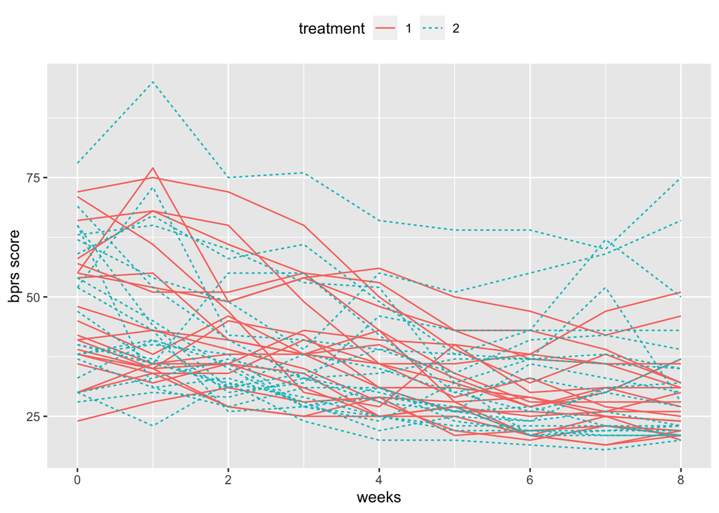

```r
Fitted <- fitted(fit4)
BPRSL <- BPRSL %>% mutate(Fitted)

plot2 <- ggplot(BPRSL, aes(x = week, y = Fitted, group = subject)) +
        geom_line(aes(linetype = treatment, color=treatment)) +
        scale_x_continuous(name = "weeks", breaks = seq(0, 8, by=2)) +
        scale_y_continuous(name = "fitted values") +
        theme(legend.position = "top")

plot1
```

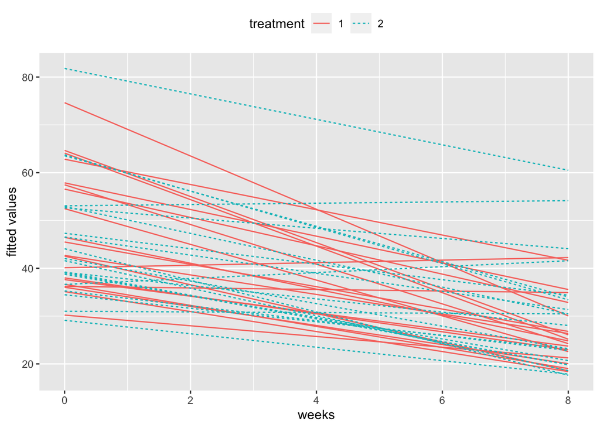

```r
plot2
```